# Datenauswertung

# Unterschiede

#### Hypothese 1:

Mitarbeiter, die mit ihren Arbeitszeiten zufrieden sind, weisen einen besseren Switch-off auf.

#### Hypothese 2

Mitarbeiter mit geringerer Arbeitszeit (bis zu 29 Std. pro Woche) und geringerer Arbeitsintensität (keine Überstunden) weisen einen besseren Switch-off auf.

Es gibt keinen signifikanten unterschied zwischen der Arbeitszeit und dem Switch off ($p>0.05$). Anders ist es bei der Arbeitintensität und dem Switch off, hier gibt es einen signifikanten Unterschied ($p<0.001$). Betrachtet man Arbeitszeit und -intensität in Bezug auf den Switch off, gibt es wiederum keinen signifikanten Unterschied ($p>0.05$).

#### Hypothese 3

Mitarbeiter, die länger (über den Mediansplit der Arbeitsjahre) in der aktuellen Jobposition beschäftigt sind, weisen einen besseren Switch-off auf.

Hypothese konnte nicht getestet werden.

#### Hypothese 4:

Mitarbeiter, die den Großteil der Woche (3 Tage oder mehr) nicht am Arbeitsplatz arbeiten, weisen einen schlechteren Switch-off auf.

Hypothese konnte nicht getestet werden.

#### Hypothese 5:

Mitarbeiter, die flexibel in ihrem Job sind, weisen einen besseren Switch-off und eine höhere Arbeitszufriedenheit auf.

# Korrelationen

#### Hypothese 1:

Je höher die Arbeitszufriedenheit, desto einfacher fällt der Switch-off.

Es gibt einen positiven signifikanten Zusammenhang zwischen der Arbeitszufriedenheit und dem Switch-off ($\tau = 0.123$, $p<0.001$). Das bedeutet, dass mit steigender Arbeitszufriedenheit die Fähigkeit von der Arbeit abzuschalten steigt.

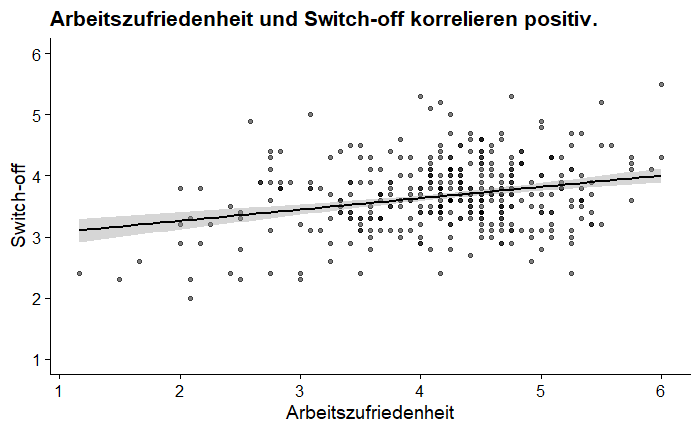

#### Hypothese 2:

Je höher die Position bei der Arbeit, desto schwieriger fällt der Switch-off.

Es gibt keinen signifikanten Zusammenhang zwischen der Position der Arbeit und dem Switch-off ($\tau=-0.054$, $p>0.05$) oder dieser konnte hier nicht festgestellt werden.

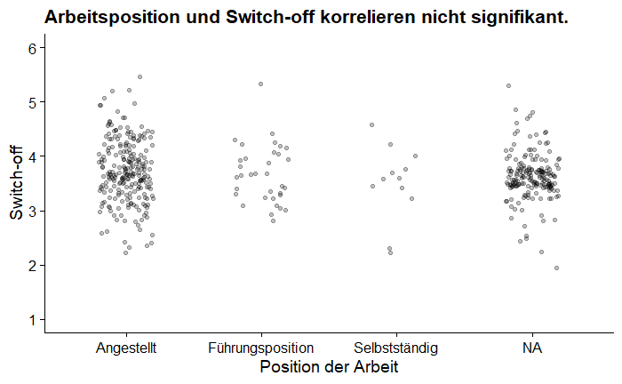

#### Hypothese 3:

Je mehr Remote Working betrieben wird, desto schwieriger fällt der Switch-off.

Es gibt keinen signifikanten Zusammenhang zwischen Remote Working und Switch-off ($\tau=-0.054$, $p>0.05$) oder dieser konnte hier nicht festgestellt werden.

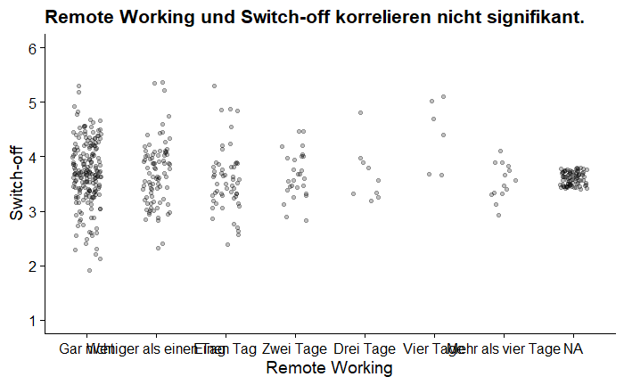

#### Hypothese 4

Je flexibler die Arbeit eingeteilt werden kann, desto höher ist die Arbeitszufriedenheit.

Es gibt einen positiven signifikanten Zusammenhang zwischen der Flexibilität der Arbeit und der Arbeitszufriedenheit ($\tau=0.241$, $p<0.001$). Die Arbeitszufriedenheit steigt, wenn die Arbeit flexibel eingeteilt werden kann.

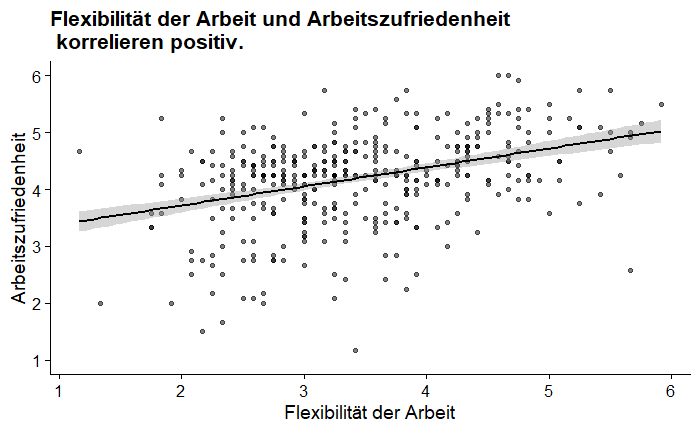

#### Hypothese 5:

Je höher die Entfernung zur Arbeit, desto einfacher fällt der Switch-off.

Es gibt keinen signifikanten Zusammenhang zwischen der Entfernung zur Arbeit und dem Switch-off ($\tau=-0.034$, $p>0.05$) oder dieser konnte hier nicht festgestellt werden.

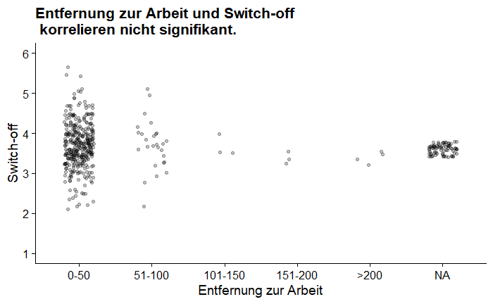

## weitere induktive Korrelationen

#### induktive Korrelation 1

Es gibt einen positiven signifikantenm Zusammenhang zwischen der Arbeitszufriedenheit und der Arbeitszeitenzufriedenheit ($\tau=0.357$, $p<0.001$). Die allgemeine Arbeitszufriedenheit steigt mir der Zufriedenheit bezüglich den Arbeitszeiten.

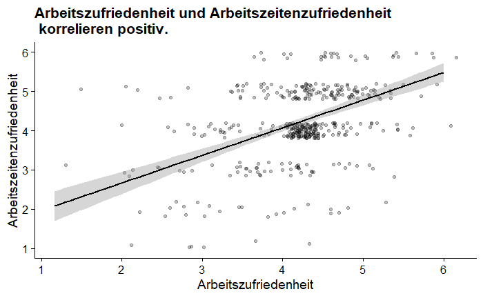

#### induktive Korrelation 2

Es gibt einen signifikanten negativen Zusammenhang zwischen der Arbeitsintensität und dem Switch-off ($\tau=-0.33$, $p<0.001$). Je höher die Arbeitsintensität, desto schwieriger fällt der Switch-off.

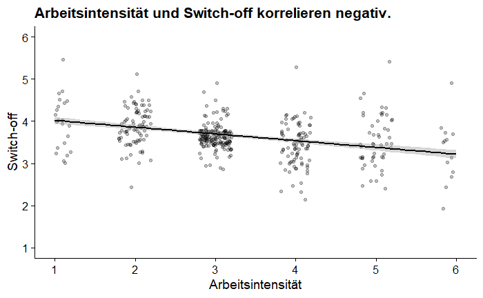

#### induktive Korrelation 3

Es gibt einen signifikanten negativen Zusammenhang zwischen der Arbeitsintensität und der Arbeitszeitenzufriedenheit ($\tau=-0.281$, $p<0.001$). Je höher die Arbeitsintensität, desto geringer ist die Arbeitszeitenzufriedenheit.

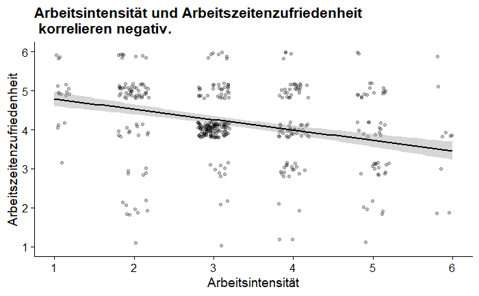